# simple-graph

## The Simplest Graph

하나의 상태와 3개의 노드로 구성된 그래프를 만들어 보자.

[figure not shown]

```python
%%capture --no-stderr
%pip install --quiet -U langgraph
```

### State

첫번째로 그래프의 상태 정보를 저장하고 노드 간 데이터 전달을 위한 스키마를 선언합니다. 이 데이터는 그래프 내 전체 노드와 엣지에 입력으로 전달될 것입니다.

`TypedDict` 클래스를 이용해 사용할 스키마를 선언합니다.

> 개인적으로 `Pydantic`이 무겁긴 하지만 코드 자체가 쉽게 이해될 것이라고 생각해서 `Pydantic`을 사용할 예정 이 문서는 `LangGraph`를 익히는 과정에서 정리하는 문서이므로 알려주는대로 정리.

```python
from typing_extensions import TypedDict

class State(TypedDict):
    graph_state: str
```

### Nodes

아래 예제에서 [Nodes](https://langchain-ai.github.io/langgraph/concepts/low_level/#nodes) 는 단지 파이썬 함수이다.

첫번째 파라미터는 위에서 정의한 상태 값입니다.

이 데이터는 `TypedDict`를 이용했으므로 각 노드에서 `state['graph_state']`를 사용하여 키 `graph_state`에 액세스할 수 있습니다.

각 노드는 상태 키 `graph_state`의 새 값을 반환합니다.

기본적으로 각 노드에서 반환되는 새 값은 이전 상태 값을 [재정의](https://langchain-ai.github.io/langgraph/concepts/low_level/#reducers)합니다.

```python
def node_1(state):
    print("---Node 1---")
    return {"graph_state": state['graph_state'] +" I am"}

def node_2(state):
    print("---Node 2---")
    return {"graph_state": state['graph_state'] +" happy!"}

def node_3(state):
    print("---Node 3---")
    return {"graph_state": state['graph_state'] +" sad!"}
```

### Edges

[Edges](https://langchain-ai.github.io/langgraph/concepts/low_level/#edges)(엣지)는 노드들을 연결한다. 엣지는 일반적으로 노드간 이동하려는 경우에 사용됩니다. 예: `node_1` 에서 `node_2`로 이동.

[Conditional Edges](https://langchain-ai.github.io/langgraph/concepts/low_level/#conditional-edges)(조건부 엣지)는 노드 간 경로를 선택하여 이동하려는 경우에 사용됩니다. 조건부 엣지는 특정 논리에 따라 다음에 방문할 노드를 반환하는 함수로 구현됩니다.

```python
import random
from typing import Literal

def decide_mood(state) -> Literal["node_2", "node_3"]:

    # Often, we will use state to decide on the next node to visit
    user_input = state['graph_state']

    # Here, let's just do a 50 / 50 split between nodes 2, 3
    if random.random() < 0.5:

        # 50% of the time, we return Node 2
        return "node_2"

    # 50% of the time, we return Node 3
    return "node_3"
```

### 그래프 생성

이제 위에서 정의한 [구성요소](https://langchain-ai.github.io/langgraph/concepts/low_level/)를 사용하여 그래프를 구축합니다. 우리는 [StateGraph 클래스](https://langchain-ai.github.io/langgraph/concepts/low_level/#stategraph)를 사용할 수 있습니다.

먼저, 위에서 정의한 `State` 클래스를 사용하여 `StateGraph`를 초기화합니다.

그런 다음 노드와 엣지를 추가합니다.

[`START` 노드](https://langchain-ai.github.io/langgraph/concepts/low_level/#start-node)는 사용자 입력을 그래프로 전송하여 그래프의 시작 위치를 나타내는 특수 노드입니다. [`END` 노드](https://langchain-ai.github.io/langgraph/concepts/low_level/#end-node)는 터미널 노드를 나타내는 특수 노드입니다.

마지막으로, 그래프 구조에 대한 몇 가지 기본적인 검사를 수행하기 위해 [그래프를 컴파일](https://langchain-ai.github.io/langgraph/concepts/low_level/#compiling-your-graph)합니다.

그래프를 [다이어그램](https://github.com/mermaid-js/mermaid)으로 시각화할 수 있습니다.

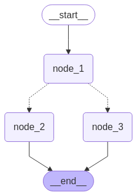

```python
from IPython.display import Image, display
from langgraph.graph import StateGraph, START, END

# Build graph
builder = StateGraph(State)
builder.add_node("node_1", node_1)
builder.add_node("node_2", node_2)
builder.add_node("node_3", node_3)

# Logic
builder.add_edge(START, "node_1")
builder.add_conditional_edges("node_1", decide_mood)
builder.add_edge("node_2", END)
builder.add_edge("node_3", END)

# Add
graph = builder.compile()

# View
display(Image(graph.get_graph().draw_mermaid_png()))
```

### Graph Invocation

컴파일된 그래프는 실행 가능한 프로토콜을 구현합니다. 이는 `LangChain` 컴포넌트를 실행하는 표준적인 방법을 제공합니다. invoke는 이 인터페이스의 표준 메서드 중 하나입니다. 입력은 그래프 상태 정보를 저장하는 `State`에 맞게 `{"graph_state": "Hi, this is jb."}` 설정하였습니다. invoke가 호출되면 그래프는 START 노드에서 실행을 시작합니다. 조건부 엣지는 '50:5'으로 '노드 1'에서 '노드 2' 또는 '노드 3'으로 이동합니다. 각 노드 함수는 현재 상태를 수신하고 그래프 상태를 재정의하는 새 값을 반환합니다. 실행은 END 노드에 도달할 때까지 계속됩니다.

```python
graph.invoke({"graph_state" : "Hi, this is jb."})
```

```
---Node 1---
---Node 2---
```

```
{'graph_state': 'Hi, this is jb. I am happy!'}
```

invoke는 전체 그래프를 동기적으로 실행합니다. 다음 단계로 넘어가기 전에 각 단계가 완료될 때까지 기다립니다. 모든 노드가 실행된 후 그래프의 최종 상태를 반환합니다. 위의 경우, '노드 2'가 호출되고 완료된 것을 알 수 있습니다.